# HW2

Author

Christine Raj

## Libraries

```r
library(ggplot2)
library(tidyverse)
library(tidytext)
library(dplyr)
library(leaflet)
library(lubridate)
library(ggpubr)
```

## Importing Data

```r
if (!file.exists("chs_individual.csv"))
download.file(
url = "https://raw.githubusercontent.com/USCbiostats/data-science-data/master/01_chs/chs_individual.csv",
destfile = "chs_individual.csv",
method = "libcurl",
timeout = 60
)
individual <- data.table::fread("chs_individual.csv")


if (!file.exists("chs_regional.csv"))
download.file(
url = "https://raw.githubusercontent.com/USCbiostats/data-science-data/master/01_chs/chs_regional.csv",
destfile = "chs_regional.csv",
method = "libcurl",
timeout = 60
)
regional <- data.table::fread("chs_regional.csv")
```

## Merging Data

```r
merge(
  # Data
  x     = individual,
  y     = regional,
  # List of variables to match
  by.x  = "townname",
  by.y  = "townname",
  # Which obs to keep?
  all.x = TRUE,
  ) %>% nrow()
```

```
[1] 1200
```

```r
chs <- merge(
  # Data
  x     = individual,
  y     = regional,
  # List of variables to match
  by.x  = "townname",
  by.y  = "townname",
  # Which obs to keep?
  all.x = TRUE,
  all.y = FALSE
  )
```

## Cleaning up Data and Making New Variables

```r
chs <- chs %>%
  group_by(male, hispanic) %>%
  mutate(agepft = ifelse(is.na(agepft), mean(agepft, na.rm = TRUE), agepft)) %>%
  mutate(height = ifelse(is.na(height), mean(height, na.rm = TRUE), height)) %>%
  mutate(weight = ifelse(is.na(weight), mean(weight, na.rm = TRUE), weight)) %>%
  mutate(bmi = ifelse(is.na(bmi), mean(bmi, na.rm = TRUE), bmi)) %>%
  mutate(fev = ifelse(is.na(fev), mean(fev, na.rm = TRUE), fev)) %>%
  mutate(fvc = ifelse(is.na(fvc), mean(fvc, na.rm = TRUE), fvc)) %>%
  mutate(mmef = ifelse(is.na(mmef), mean(mmef, na.rm = TRUE), mmef)) %>%
  mutate(no_24hr = ifelse(is.na(no_24hr), mean(no_24hr, na.rm = TRUE), no_24hr)) %>%
  mutate(pm2_5_fr = ifelse(is.na(pm2_5_fr), mean(pm2_5_fr, na.rm = TRUE), pm2_5_fr))

Mode <- function(x) {
  ux <- unique(x)
  ux[which.max(tabulate(match(x, ux)))]
}

chs <- chs %>%
  group_by(male, hispanic) %>%
  mutate(asthma = ifelse(is.na(asthma), Mode(asthma), asthma))  %>%
  mutate(active_asthma = ifelse(is.na(active_asthma), Mode(active_asthma), active_asthma)) %>%
  mutate(father_asthma = ifelse(is.na(father_asthma), Mode(father_asthma), father_asthma)) %>%
   mutate(mother_asthma = ifelse(is.na(mother_asthma), Mode(mother_asthma), mother_asthma)) %>%
  mutate(wheeze = ifelse(is.na(wheeze), Mode(wheeze), wheeze)) %>%
  mutate(hayfever = ifelse(is.na(hayfever), Mode(hayfever), hayfever)) %>%
  mutate(allergy = ifelse(is.na(allergy), Mode(allergy), allergy)) %>%
  mutate(educ_parent = ifelse(is.na(educ_parent), Mode(educ_parent), educ_parent)) %>%
  mutate(smoke = ifelse(is.na(smoke), Mode(smoke), smoke)) %>%
  mutate(pets = ifelse(is.na(pets), Mode(pets), pets)) %>%
  mutate(gasstove = ifelse(is.na(gasstove), Mode(gasstove), gasstove))

table(is.na(chs))
```

```
FALSE
58800
```

```r
chs$obesity_level <- ifelse(chs$bmi < 14, "underweight",
                           ifelse(chs$bmi < 22 & chs$bmi >= 14, "normal",
                                  ifelse(chs$bmi >= 22 & chs$bmi < 24, "overweight",
                                       ifelse(chs$bmi >= 24, "obese", NA))))
summary_obesitylevel <- chs %>%
  group_by(obesity_level) %>%
  summarize(
    min_BMI = min(bmi, na.rm = TRUE),
    max_BMI = max(bmi, na.rm = TRUE),
    total_observations = n()
  )
print(summary_obesitylevel)
```

```
# A tibble: 4 × 4
  obesity_level min_BMI max_BMI total_observations
  <chr>           <dbl>   <dbl>              <int>
1 normal           14.0    22.0                975
2 obese            24.0    41.3                103
3 overweight       22.0    24.0                 87
4 underweight      11.3    14.0                 35
```

```r
chs$smoke_gas_exposure <- ifelse(chs$smoke == 0 & chs$gasstove == 0, "no smoke exposure",
                           ifelse(chs$smoke == 1 & chs$gasstove == 0, "Second hand smoke",
                                 ifelse(chs$smoke == 0 & chs$gasstove == 1, "gas stove exposure",
                                      ifelse(chs$smoke == 1 & chs$gasstove == 1, "both smoke and gasstove exposure", NA))))

chs %>%
  group_by(chs$smoke_gas_exposure) %>%
  count(chs$smoke_gas_exposure)
```

```
# A tibble: 4 × 2
# Groups:   chs$smoke_gas_exposure [4]
  `chs$smoke_gas_exposure`             n
  <chr>                            <int>
1 Second hand smoke                   36
2 both smoke and gasstove exposure   154
3 gas stove exposure                 791
4 no smoke exposure                  219
```

```r
mean_town <- chs %>%
  group_by(chs$townname) %>%
  summarize(
    meanFEV = mean(fev, na.rm = TRUE),
    sdFEV = sd(fev, na.rm = TRUE))
print(mean_town)
```

```
# A tibble: 12 × 3
   `chs$townname` meanFEV sdFEV
   <chr>            <dbl> <dbl>
 1 Alpine           2087.  291.
 2 Atascadero       2076.  324.
 3 Lake Elsinore    2039.  304.
 4 Lake Gregory     2085.  320.
 5 Lancaster        2003.  317.
 6 Lompoc           2034.  351.
 7 Long Beach       1986.  319.
 8 Mira Loma        1985.  325.
 9 Riverside        1990.  278.
10 San Dimas        2027.  319.
11 Santa Maria      2026.  312.
12 Upland           2024.  343.
```

```r
FEV_sex <- chs %>%
  group_by(male) %>%
  summarize(
    meanFEVsex = mean(fev),
    sdFEVsex = sd(fev))
print(FEV_sex)
```

```
# A tibble: 2 × 3
   male meanFEVsex sdFEVsex
  <int>      <dbl>    <dbl>
1     0      1959.     312.
2     1      2104.     308.
```

```r
FEV_obesity_level <- chs %>%
  group_by(obesity_level) %>%
  summarize(
    meanFEVobesity = mean(fev),
    sdFEVobesity = sd(fev))
print(FEV_obesity_level)
```

```
# A tibble: 4 × 3
  obesity_level meanFEVobesity sdFEVobesity
  <chr>                  <dbl>        <dbl>
1 normal                 2000.         295.
2 obese                  2266.         325.
3 overweight             2224.         317.
4 underweight            1698.         303.
```

```r
FEV_smokegas <- chs %>%
  group_by(smoke_gas_exposure) %>%
  summarize(
    meanFEVsomkegas = mean(fev),
    sdFEVsmokegas = sd(fev))
print(FEV_smokegas)
```

```
# A tibble: 4 × 3
  smoke_gas_exposure               meanFEVsomkegas sdFEVsmokegas
  <chr>                                      <dbl>         <dbl>
1 Second hand smoke                          2056.          296.
2 both smoke and gasstove exposure           2025.          301.
3 gas stove exposure                         2023.          319.
4 no smoke exposure                          2057.          329.
```

## Looking at the Data

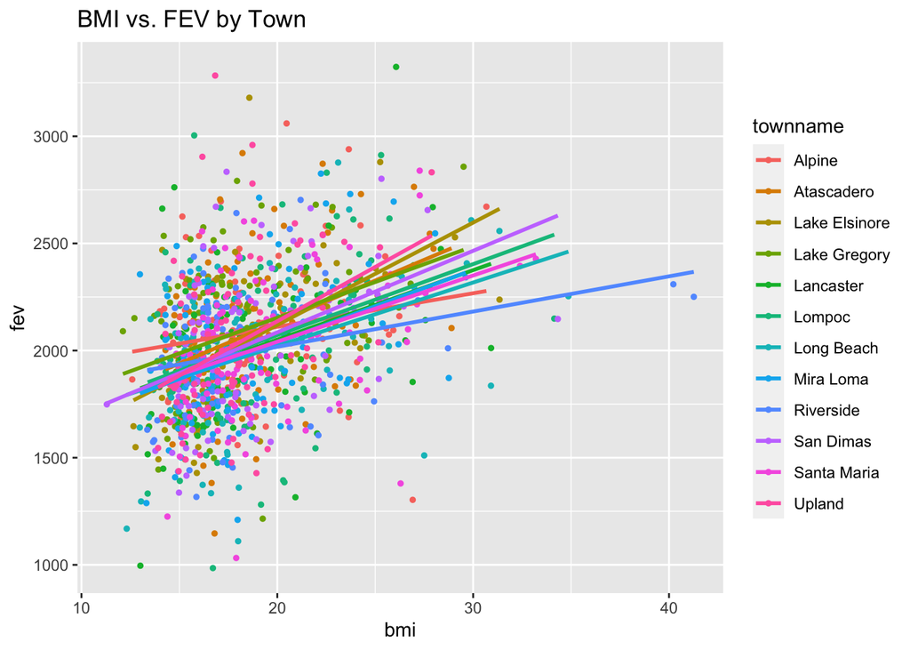

```r
ggplot(chs, aes(x = bmi, y = fev, group = townname, color = townname)) +
  geom_point (size = 1) +
  labs(
    title = "BMI vs. FEV by Town",
    x = "bmi",
    y = "fev"
  ) + geom_smooth(method = "lm", se = FALSE)
```

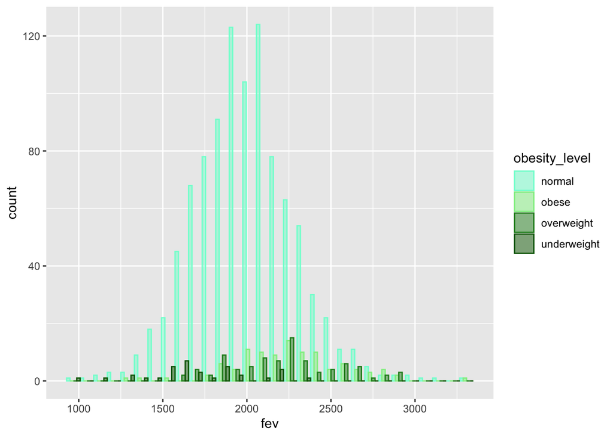

```r
custom_colors <- c("turquoise", "coral", "purple", "pink")
custcolor2 <- c("aquamarine", "lightgreen", "forestgreen", "darkgreen")

chs %>%
  ggplot(aes(x = fev, fill = obesity_level, color = obesity_level)) +
  geom_histogram(alpha = 0.5, position = "dodge") +
  scale_fill_manual(values = custcolor2) +
  scale_color_manual(values = custcolor2)
```

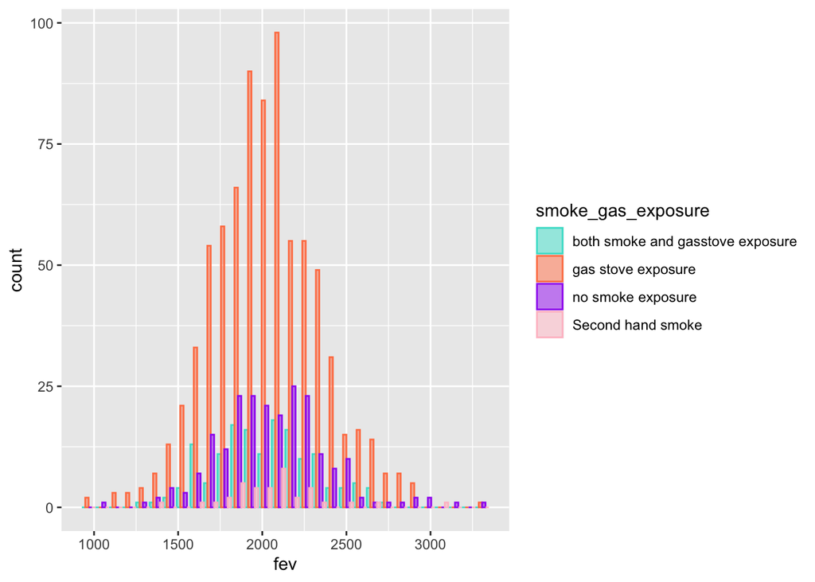

```r
chs %>%
  ggplot(aes(x = fev, fill = smoke_gas_exposure, color = smoke_gas_exposure)) +
  geom_histogram(alpha = 0.5, position = "dodge") +
  scale_fill_manual(values = custom_colors) +
  scale_color_manual(values = custom_colors)
```

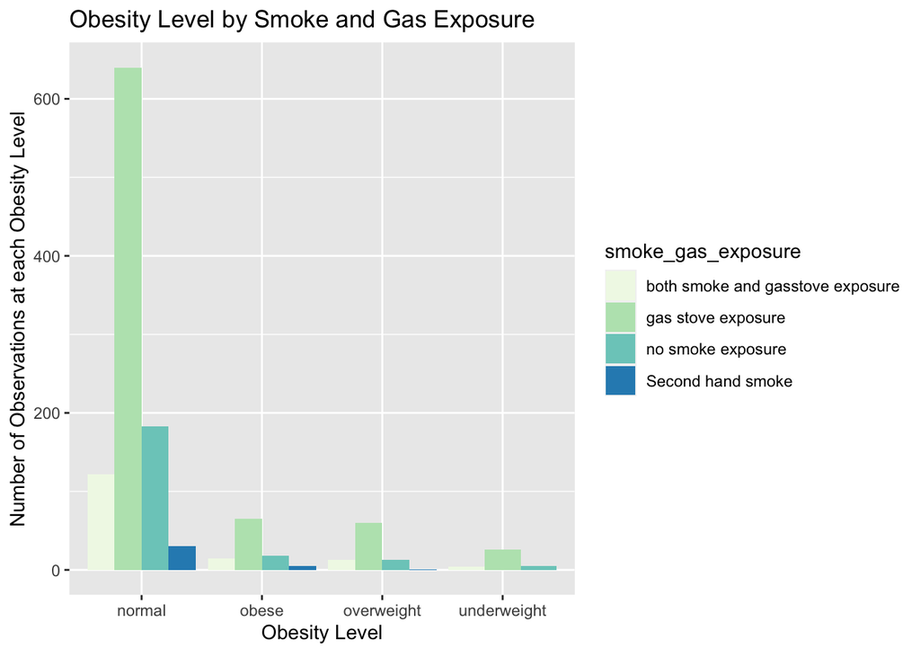

```r
chs %>%
  ggplot() +
  geom_bar(mapping = aes(x = chs$obesity_level, fill = smoke_gas_exposure), position = "dodge") +
  scale_fill_brewer(palette = 4) +
  labs(title = "Obesity Level by Smoke and Gas Exposure") +
  labs(x = expression("Obesity Level"), y = "Number of Observations at each Obesity Level")
```

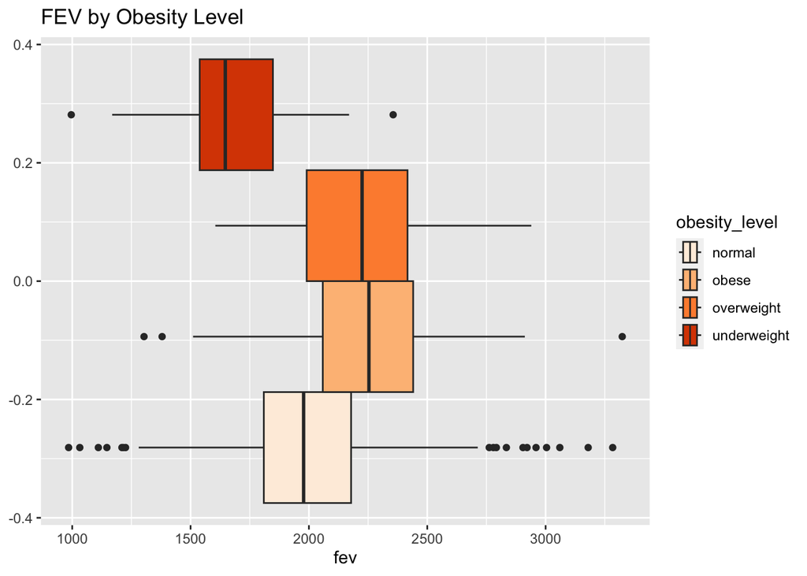

```r
chs %>%
  ggplot() +
  geom_boxplot(mapping = aes(x = fev, fill = obesity_level), position = "dodge") +
  scale_fill_brewer(palette = 7) +
  labs(title = "FEV by Obesity Level") +
  labs(x = expression("fev"))
```

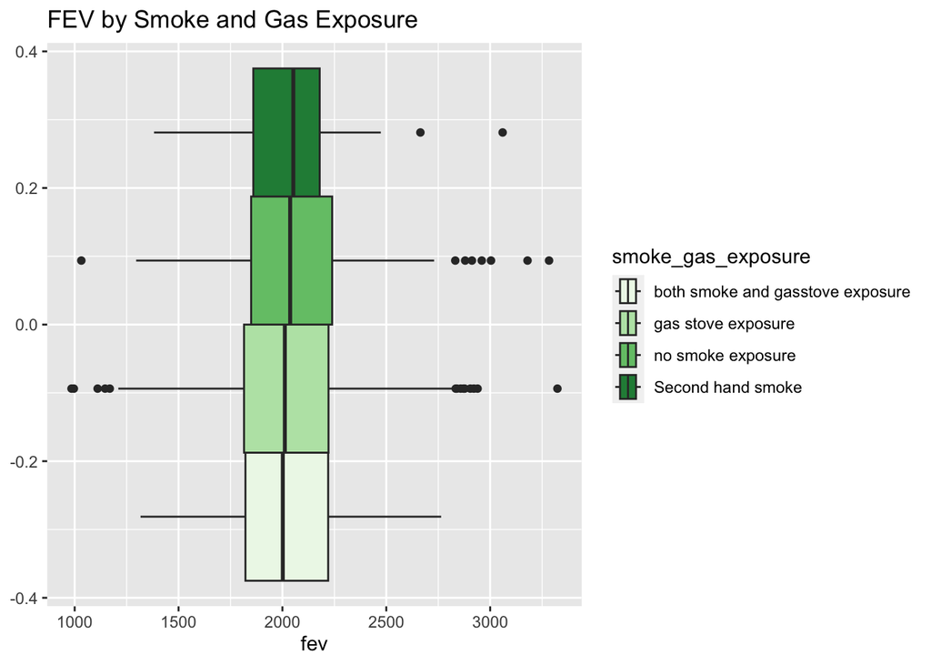

```r
chs %>%
  ggplot() +
  geom_boxplot(mapping = aes(x = fev, fill = smoke_gas_exposure), position = "dodge") +
  scale_fill_brewer(palette = 5) +
  labs(title = "FEV by Smoke and Gas Exposure") +
  labs(x = expression("fev"))
```

```r
PM25.pal <- colorNumeric(c("aquamarine", "lightgreen", "forestgreen", "darkgreen"), domain=chs$pm25_mass)
PM25.pal
```

[output not shown]

```r
PM25map <- leaflet(chs) %>%
  # The looks of the Map
  addProviderTiles('CartoDB.Positron') %>%
  # Some circles
  addCircles(
    lat = ~lat, lng=~lon,
                                                  # HERE IS OUR PAL!
    label = ~paste0(round(pm25_mass,2), ' C'), color = ~ PM25.pal(pm25_mass),
    opacity = 1, fillOpacity = 1, radius = 500
    ) %>%
  #Add text
  addLabelOnlyMarkers(
    lat = ~lat, lng = ~lon, label = ~paste0(round(pm25_mass, 2), ' C'),
    labelOptions = labelOptions(noHide = TRUE, direction = 'right')
  ) %>%
  # And a pretty legend
  addLegend('bottomleft', pal=PM25.pal, values=chs$pm25_mass,
          title='PM2.5 mass', opacity=1)
PM25map
```

[interactive chart not shown]

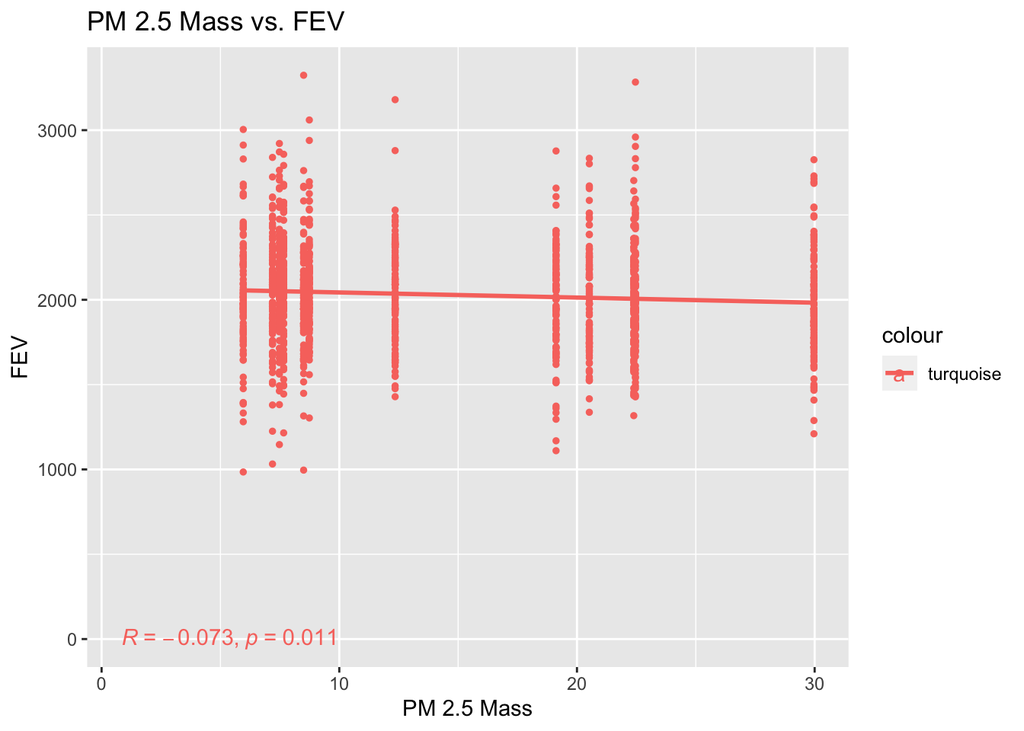

```r
ggplot(chs, aes(x = pm25_mass , y = fev, color = 'turquoise')) +
  geom_point (size = 1) +
  labs(
    title = "PM 2.5 Mass vs. FEV",
    x = "PM 2.5 Mass",
    y = "FEV"
  ) + geom_smooth(method = "lm", se = FALSE) +
  stat_cor(method = "pearson", label.x = 0.85, label.y = 1)
```

1. What is the association between BMI and FEV (forced expiratory volume)?

   There is a positive association between BMI and FEV level as the lower the obesity level the lower the FEV. As obesity level goes up, the FEV also goes higher. There is less of a difference in FEV once a person is categorized as overweight or obese, but there is a significant difference between underweight and normal BMI’s compared to overweight and obese.
2. What is the association between smoke and gas exposure and FEV?

   There is no association between smoke and gas exposure and FEV because the medians and the quartile ranges are all fairly similar. There are a some more outliers in the categories that have either no smoke exposure or just gas stove exposure.
3. What is the association between PM2.5 exposure and FEV?